# STAT40730 FINAL PROJECT

Author

Shubh Gaur - 23200555

## Important Note

When running all code chunks together, a prompt to restart R with the installed packages loaded will be displayed. Simply click cancel or restart R and run all code chunks after commenting **install.packages()** function usages in the qmd.

## Importing Libraries

```r
library(readxl)
library(tidyverse)
library(knitr)
library(gridExtra)
```

## A

### Dataset Description

We are going to work with a dataset which contains information about student entrants, students enrolled(either part time or full time) in third level courses across various Irish Universities for the years 2000 - 2017.

We aim to generate useful insights using this data so that we can better understand about demography of Ireland’s higher level education. Link to the dataset: https://data.cso.ie/table/EDA99

### Importing the dataset

Lets begin with importing the dataset.

```r
third_level_education_data <- read_excel("data.xlsx")
head(third_level_education_data,width = 84, strict.width = "cut")
```

```
# A tibble: 6 × 5
  Institution                Year  Full-time Enrolments…¹ Part-time Enrolments…²
  <chr>                      <chr>                  <dbl>                  <dbl>
1 Higher Education Authority 2000                   66914                  11305
2 Higher Education Authority 2001                   69254                  11313
3 Higher Education Authority 2002                   72168                  13826
4 Higher Education Authority 2003                   74922                  14036
5 Higher Education Authority 2004                   77491                  13420
6 Higher Education Authority 2005                   78970                  16166
# ℹ abbreviated names: ¹`Full-time Enrolments to Third Level Courses (Number)`,
#   ²`Part-time Enrolments to Third Level Courses (Number)`
# ℹ 1 more variable: `Entrants to Third Level Courses (Number)` <dbl>
```

### Data Preprocessing

The column names are too big lets modify them for our convenience.

```r
names(third_level_education_data)=c("Institution","Year","Full Time Enrolments","Part Time Enrolments","New Entrants")
head(third_level_education_data,width = 84, strict.width = "cut")
```

```
# A tibble: 6 × 5
  Institution Year  `Full Time Enrolments` `Part Time Enrolments` `New Entrants`
  <chr>       <chr>                  <dbl>                  <dbl>          <dbl>
1 Higher Edu… 2000                   66914                  11305          16505
2 Higher Edu… 2001                   69254                  11313          16210
3 Higher Edu… 2002                   72168                  13826          16654
4 Higher Edu… 2003                   74922                  14036          16756
5 Higher Edu… 2004                   77491                  13420          17454
6 Higher Edu… 2005                   78970                  16166          17560
```

Lets have a look at structure of the data using str() function.

```r
str(third_level_education_data,width = 84, strict.width = "cut")
```

```
tibble [756 × 5] (S3: tbl_df/tbl/data.frame)
 $ Institution         : chr [1:756] "Higher Education Authority" "Higher Educati"..
 $ Year                : chr [1:756] "2000" "2001" "2002" "2003" ...
 $ Full Time Enrolments: num [1:756] 66914 69254 72168 74922 77491 ...
 $ Part Time Enrolments: num [1:756] 11305 11313 13826 14036 13420 ...
 $ New Entrants        : num [1:756] 16505 16210 16654 16756 17454 ...
```

It is clear from the above output that each variable has **756** observations which might reduce post dropping rows with missing values, if present. Furthermore, the variables **Full Time Enrolments**, **Part Time Enrolments**, **New Entrants** is of the form numeric whereas variables **Institution** & **Year** contain categorical(character/textual) data.

#### Handling missing data

Lets check for missing values in the data by negating the output of **complete.cases()** function on our data set. If we try to find the sum of this logical vector we will get the frequency of **1s** which will tell us about the count of missing values.

```r
cat(paste("Number of records with missing entries = ",sum(!complete.cases(third_level_education_data))))
```

```
Number of records with missing entries =  192
```

It is clear from the output that our data has 192 rows with missing values. Lets remove these rows and see the count of missing values.

```r
third_level_education_data <- filter(third_level_education_data,complete.cases(third_level_education_data))
cat(paste("Number of records with missing entries = ",sum(!complete.cases(third_level_education_data))))
```

```
Number of records with missing entries =  0
```

The data is now rid of missing values.

#### Transforming data (numeric and categorical)

Now, We will take care of the categorical data that we have by converting the character variables into **factors** and having a look at unique values through **levels** of the factor.

```r
levels(factor(third_level_education_data$Institution))
```

```
 [1] "Aided technology sector"
 [2] "Aided university sector"
 [3] "Athlone Institute of Technology"
 [4] "C.O.I. College of Education, Rathmines, Dublin"
 [5] "Colaiste Mhuire, Marino, Dublin"
 [6] "Cork Institute of Technology"
 [7] "Dublin City University"
 [8] "Dublin Institute of Technology"
 [9] "Dun Laoghaire Institute of Art, Design and Technology"
[10] "Dundalk Institute of Technology"
[11] "Froebel College, Blackrock, Co. Dublin"
[12] "Galway - Mayo Institute of Technology"
[13] "Higher Education Authority"
[14] "Institute of Technology, Blanchardstown"
[15] "Institute of Technology, Carlow"
```

[output cut: 26 more lines]

The dataset contains data from **41** different institutes within **Ireland** which is clear from the above output i.e **41** levels.

```r
levels(factor(third_level_education_data$Year))
```

```
 [1] "2000" "2001" "2002" "2003" "2004" "2005" "2006" "2007" "2008" "2009"
[11] "2010" "2011" "2012" "2013" "2014" "2015" "2016" "2017"
```

The dataset contains data from **2000 - 2017** of different institutes within **Ireland** which is clear from the above output.

Now, we are sure that these variables are perfect for categorical conversion.

We will be modifying the original dataframe by converting the character variables to categorical.

```r
third_level_education_data$Institution <-  factor(third_level_education_data$Institution)
third_level_education_data$Year <-  factor(third_level_education_data$Year)
str(third_level_education_data,width = 84, strict.width = "cut")
```

```
tibble [564 × 5] (S3: tbl_df/tbl/data.frame)
 $ Institution         : Factor w/ 41 levels "Aided technology sector",..: 13 13 1..
 $ Year                : Factor w/ 18 levels "2000","2001",..: 1 2 3 4 5 6 7 8 1 2..
 $ Full Time Enrolments: num [1:564] 66914 69254 72168 74922 77491 ...
 $ Part Time Enrolments: num [1:564] 11305 11313 13826 14036 13420 ...
 $ New Entrants        : num [1:564] 16505 16210 16654 16756 17454 ...
```

### Inferences drawn using exploratory data analysis

The next steps involve performing **exploratory data analysis** on the data to gain better understanding of data and gain some useful insights from it.

Lets check the mean number of **full time enrolments** across all institutions in **Ireland** for all the years.

```r
enrolments_ftime <- tapply(third_level_education_data$`Full Time Enrolments`,third_level_education_data$Year,mean) |> sort(decreasing = TRUE)
mean_full_time_enrolments_per_year <- data.frame(Year = as.numeric(names(enrolments_ftime)), Mean_Value = as.integer(enrolments_ftime))
colnames(mean_full_time_enrolments_per_year)=c("Year","Mean Full Time Enrolments")

kable(mean_full_time_enrolments_per_year,booktabs = TRUE)
```

| Year | Mean Full Time Enrolments |
| --- | --- |
| 2007 | 13748 |
| 2017 | 12069 |
| 2016 | 11534 |
| 2015 | 10501 |
| 2014 | 10253 |
| 2012 | 10168 |
| 2013 | 9987 |
| 2011 | 9484 |
| 2010 | 8951 |
| 2009 | 8574 |
| 2008 | 8403 |
| 2005 | 8332 |
| 2002 | 8271 |
| 2006 | 8022 |
| 2001 | 7967 |
| 2004 | 7852 |
| 2000 | 7682 |
| 2003 | 7582 |

Now we will list the data using the same methodology for variables **Part time enrolment** and **New Entrants**.

```r
enrolments_ptime <- tapply(third_level_education_data$`Part Time Enrolments`,third_level_education_data$Year,mean) |> sort(decreasing = TRUE)
mean_part_time_enrolments_per_year <- data.frame(Year = as.numeric(names(enrolments_ptime)), Mean_Value = as.integer(enrolments_ptime))
colnames(mean_part_time_enrolments_per_year)=c("Year","Mean Part Time Enrolments")

kable(mean_part_time_enrolments_per_year,booktabs = TRUE)
```

| Year | Mean Part Time Enrolments |
| --- | --- |
| 2017 | 2641 |
| 2007 | 2601 |
| 2016 | 2542 |
| 2002 | 2331 |
| 2015 | 2240 |
| 2014 | 2191 |
| 2013 | 2168 |
| 2005 | 2156 |
| 2001 | 2151 |
| 2012 | 2111 |
| 2000 | 2097 |
| 2008 | 2053 |
| 2003 | 2040 |
| 2004 | 2000 |
| 2009 | 1942 |
| 2011 | 1915 |
| 2010 | 1873 |
| 2006 | 1844 |

Lets check the mean number of enrolments across all institutions in **Ireland** for all the years.

```r
new_entrants <- tapply(third_level_education_data$`New Entrants`,third_level_education_data$Year,mean) |> sort(decreasing = TRUE)
mean_new_entrants_per_year <- data.frame(Year = as.numeric(names(new_entrants)), Mean_Value = as.integer(new_entrants))
colnames(mean_new_entrants_per_year)=c("Year","Mean Number of New Entrants")

kable(mean_new_entrants_per_year,booktabs = TRUE)
```

| Year | Mean Number of New Entrants |
| --- | --- |
| 2007 | 3171 |
| 2017 | 2932 |
| 2016 | 2841 |
| 2015 | 2596 |
| 2012 | 2581 |
| 2014 | 2560 |
| 2013 | 2524 |
| 2011 | 2423 |
| 2000 | 2376 |
| 2010 | 2356 |
| 2001 | 2354 |
| 2002 | 2337 |
| 2009 | 2310 |
| 2008 | 2205 |
| 2005 | 2147 |
| 2004 | 2084 |
| 2006 | 2070 |
| 2003 | 2059 |

Lets visualize the top **10** institutes with respect to mean number of enrolments (part time and full time) and mean number of new entrants over the period **2000 - 2017**.

```r
result <- third_level_education_data %>%
  group_by(Institution) %>%
  summarise(mean_enrolments = mean(`Full Time Enrolments`)) %>%
  arrange(desc(mean_enrolments)) %>%
  head(10)
result
```

```
# A tibble: 10 × 2
   Institution                                        mean_enrolments
   <fct>                                                        <dbl>
 1 Aided university sector                                     91203.
 2 Higher Education Authority                                  75376
 3 Aided technology sector                                     62869.
 4 Institutes of Technology/Other Technology Colleges          50769.
 5 National University of Ireland, Dublin                      18207.
 6 National University of Ireland, Cork                        14488.
 7 Trinity College, Dublin                                     13139.
 8 National University of Ireland, Galway                      12299.
 9 Dublin Institute of Technology                              11435.
10 University of Limerick                                       9937.
```

From the output above, its difficult to see the top 10 colleges because collective groups[considering multiple colleges] are included which is a hindrance in getting top 10 individual institute names which have most number of mean_enrolments over all the years.  
We can handle this by excluding these collective groups of institute from the dataset which will let us focus on individual institutes. Lets find these collective groups by seeing the **levels** of variable institution to find unique entries.

```r
levels(third_level_education_data$Institution)
```

```
 [1] "Aided technology sector"
 [2] "Aided university sector"
 [3] "Athlone Institute of Technology"
 [4] "C.O.I. College of Education, Rathmines, Dublin"
 [5] "Colaiste Mhuire, Marino, Dublin"
 [6] "Cork Institute of Technology"
 [7] "Dublin City University"
 [8] "Dublin Institute of Technology"
 [9] "Dun Laoghaire Institute of Art, Design and Technology"
[10] "Dundalk Institute of Technology"
[11] "Froebel College, Blackrock, Co. Dublin"
[12] "Galway - Mayo Institute of Technology"
[13] "Higher Education Authority"
[14] "Institute of Technology, Blanchardstown"
[15] "Institute of Technology, Carlow"
```

[output cut: 26 more lines]

Let’s create a list of collective institution groups and remove them from the dataset using **filter** function.

```r
# initialising a list containing grouped institution
institutes_to_remove <- c("Aided university sector", "Higher Education Authority", "Aided technology sector", "Institutes of Technology/Other Technology Colleges","Teacher education colleges","Other colleges","Other third level education institutions aided by DES")

# Filter out rows which don't belong to the specified institutes names
education_data_individual_institutes <- third_level_education_data %>%
  filter(!Institution %in% institutes_to_remove)
```

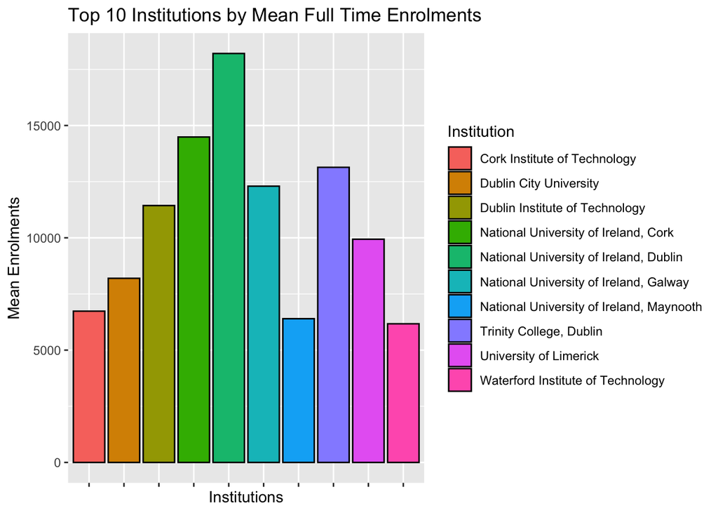

```r
result <- education_data_individual_institutes %>%
  group_by(Institution) %>%
  summarise(mean_enrolments = mean(`Full Time Enrolments`)) %>%
  arrange(desc(mean_enrolments)) %>%
  head(10)

ggplot(result, aes(x = Institution, y = mean_enrolments, fill = Institution)) +
  geom_bar(stat = "identity", color = "black") +
  labs(title = "Top 10 Institutions by Mean Full Time Enrolments",
       x = "Institutions",
       y = "Mean Enrolments") +
  theme(axis.text.x = element_blank(),  # Remove x-axis text
        legend.position = "right")  # Move legend to the bottom
```

From the above plot its clear that **National University of Ireland, Dublin** had the highest number of fulltime enrolments(in average) over the span of 17 years.

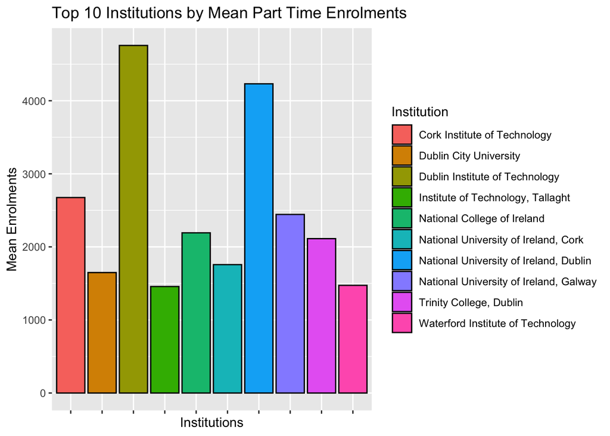

```r
result <- education_data_individual_institutes %>%
  group_by(Institution) %>%
  summarise(mean_enrolments = mean(`Part Time Enrolments`)) %>%
  arrange(desc(mean_enrolments)) %>%
  head(10)

ggplot(result, aes(x = Institution, y = mean_enrolments, fill = Institution)) +
  geom_bar(stat = "identity", color = "black") +
  labs(title = "Top 10 Institutions by Mean Part Time Enrolments",
       x = "Institutions",
       y = "Mean Enrolments") +
  theme(axis.text.x = element_blank(),  # Remove x-axis text
        legend.position = "right")  # Move legend to the bottom
```

From the above plot, it is clear that **Dublin Institute of Technology** had the highest number of part time enrolments(in average) over the span of 17 years.

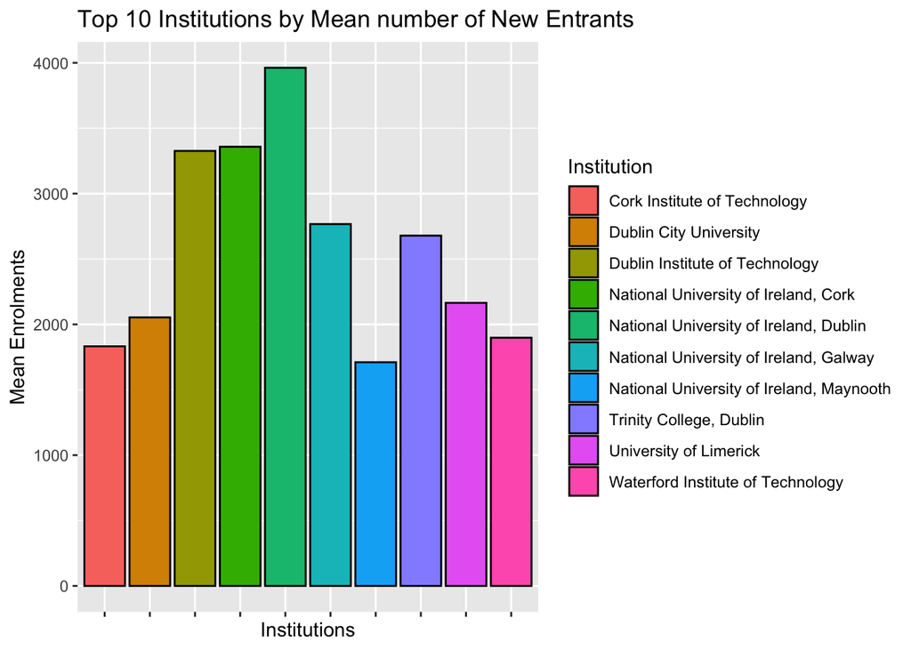

```r
result <- education_data_individual_institutes %>%
  group_by(Institution) %>%
  summarise(mean_new_entrants = mean(`New Entrants`)) %>%
  arrange(desc(mean_new_entrants)) %>%
  head(10)

ggplot(result, aes(x = Institution, y = mean_new_entrants, fill = Institution)) +
  geom_bar(stat = "identity", color = "black") +
  labs(title = "Top 10 Institutions by Mean number of New Entrants",
       x = "Institutions",
       y = "Mean Enrolments") +
  theme(axis.text.x = element_blank(),  # Remove x-axis text
        legend.position = "right")  # Move legend to the bottom
```

From the above plot its clear that **National University of Ireland, Dublin** had the highest number of new entrants(in average) over the span of 17 years.

Lets now try to visualize the trend of enrolments (both part time and full time) and new entrants over the years.

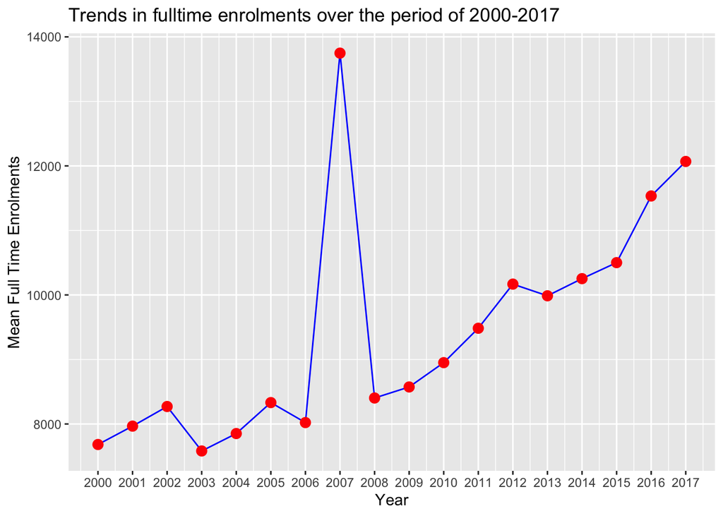

```r
ggplot(mean_full_time_enrolments_per_year, aes(x = Year, y = `Mean Full Time Enrolments`)) +
  geom_line(color = "blue") +
  geom_point(color = "red", size = 3) +
  labs(title = "Trends in fulltime enrolments over the period of 2000-2017") +
  scale_x_continuous(n.breaks=16) #16 breaks for period of 17 years
```

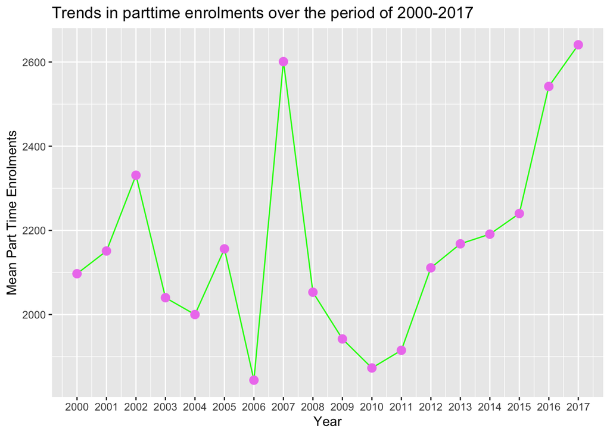

```r
ggplot(mean_part_time_enrolments_per_year, aes(x = Year, y = `Mean Part Time Enrolments`)) +
  geom_line(color = "green") +
  geom_point(color = "violet", size = 3) +
  labs(title = "Trends in parttime enrolments over the period of 2000-2017") +
  scale_x_continuous(n.breaks=16) #16 breaks for period of 17 years
```

From the above trend plot, we infer that year **2017** had the most number of part time enrolments while year **2006** had the least number of part time enrolments across various institutions in Ireland.

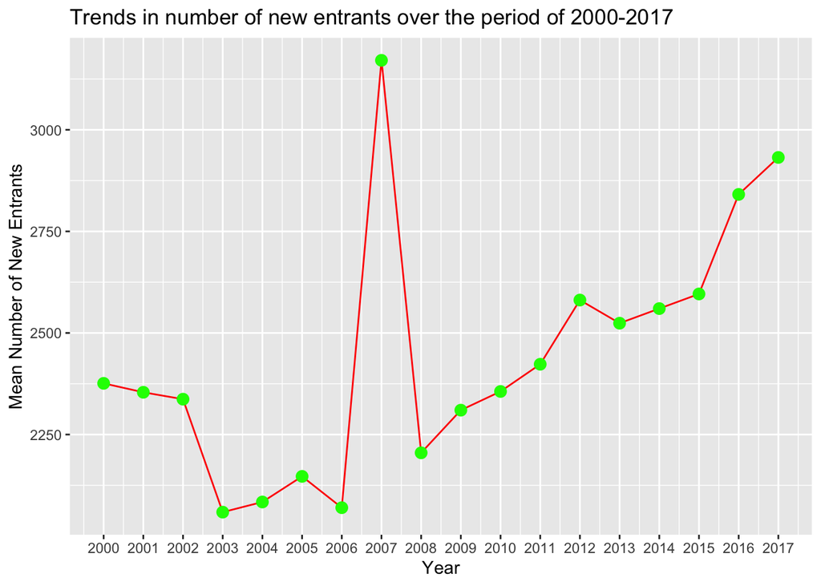

```r
ggplot(mean_new_entrants_per_year, aes(x = Year, y = `Mean Number of New Entrants`)) +
  geom_line(color = "red") +
  geom_point(color = "green", size = 3) +
  labs(title = "Trends in number of new entrants over the period of 2000-2017") +
  scale_x_continuous(n.breaks=16) #16 breaks for period of 17 years
```

From the above trend plot, we infer that year **2007** had the most number of new entrants(in average) while year **2003** had the least number of new entrants across various institutions in Ireland.

## B

### Package Description : reticulate

The reticulate package in R provides an interface to Python from R. It allows us to run Python code within an R session, call Python functions, access Python objects, and even pass data between R and Python. Essentially, reticulate facilitates interoperability between R and Python, enabling you to leverage the strengths of both programming languages in a single analysis or project.

Link: https://cran.r-project.org/web/packages/reticulate/index.html

### Setting up the python environment using reticulate

Before we can use this package’s functionality to run python code we need to set up a few things such as python interpreter,virtual environment and the packages that we wish to use.

The first step will be to set up the python interpretor. We can install the python version of our choice using **install_python** function which inputs **version** as a parameter and installs the python interpretor pertaining to the passed version.

```r
python_version <- "3.9"
install_python(version=python_version)
```

```
[1] "/Users/shubhgaur/.pyenv/versions/3.9.18/bin/python3.9"
```

The second step is to create a virtual environment which will use the installed python version. We can create the python virtual environment **virtual_env.create()** function which inputs parameters such as:

- **envname** : lets us specify the name for the virtual environment.
- **version** : lets us specify the python version to use for creating the environment.

```r
virtualenv_create(envname="RPythonEnv",version=python_version)
```

```
virtualenv: RPythonEnv
```

We are now ready to execute python code on R.

But prior to that we need to specify the environment to use for executing our python code which can be done using **use_virtualenv** function which inputs envname to be used which is demonstrated below.

```r
use_virtualenv(virtualenv="RPythonEnv")
```

### Basic Operations

Lets start executing python code in R.

We can use **py_run_string()** function to execute python code.

We can write some python code and store the result in python variables those python variables will be added in the fields of py_run_string() functions objects.

Lets demonstrate its use to make things clear.

```r
py_run_string("print('This is R to Python')")
```

```
This is R to Python
```

```r
py_run_string("a=10/20")$a
```

```
[1] 0.5
```

```r
py_run_string("")$a
```

```
[1] 0.5
```

In the first line we are trying to print a string, if we use python’s print function then the corresponding R output will be identical to the output provided by cat() function.

In the second line, we create a variable **a** in python and assign it value 10/20. Since a is created,it will be added to the fields of py_run_string() object.

In the third line we are trying to show that the the field **a** which was returned is global and will not change or diminish with different invocations of **py_run_string()** function.

Now, Lets try to create a dictionary in python and see what is the corresponding R format.

```r
dict_python_to_r <- py_run_string("d={'hello':'hi','tata':'bye'}")$d
dict_python_to_r
```

```
$hello
[1] "hi"

$tata
[1] "bye"
```

```r
class(dict_python_to_r)
```

```
[1] "list"
```

R stores a python dictionary in the form of lists.

### Advanced Operations

Now, we will move onto performing some advanced operations such as importing libraries as objects, accessing their functions, etc. We will mainly be demonstrating this on data manipulation libraries such as **pandas** and visualisation libraries such as **matplotlib**.

We can install the libraries that we wish to use using **py_install()** function which takes library_name as the input.

We can import any installed python library into a R object using **import()** function and then use the object name as an alias to call the related functions in the library.

If we want to use any function from the imported library we need to call on it using the **$** operator.

(Note: **.** operator is used in python to access functions from a module or methods of an object).

We will be demonstrating the use of **pandas** library including but not limited to dataframe conversions from R to python, accessing functions from this module, and **matplotlib** library to plot pie graph for the data used in the previous section. But prior to using matplotlib for visualisation we will need to convert our R dataframe to python dataframe using pandas library.

We will be using the **result** dataframe that we created earlier which contains information of top 10 institutions in Ireland with respect to mean number of new_entrants.

```r
pd <- import("pandas")
plt <-import("matplotlib.pyplot")

#converting R dataframe to python dataframe
result_pandas <- pd$DataFrame(result)

#printing first 5 rows using head function in python
pd$DataFrame$head(result_pandas)
```

```
                             Institution mean_new_entrants
1 National University of Ireland, Dublin          3962.389
2   National University of Ireland, Cork          3358.389
3         Dublin Institute of Technology          3326.471
4 National University of Ireland, Galway          2767.000
5                Trinity College, Dublin          2678.722
```

Now, lets plot the pie chart which depicts the proportion of **mean number of new entrants** among the top 10 institutions by mean number of new entrants in Ireland over the period **2000-2017**

We have saved the plot in a png file. Now, we will use the png file to embed the plot in the markdown document.

**Note**: We are not using **plt.show()** method to view the plot because it was opening in a separate window when the document was being rendered and rendered html was not opening until the pie chart was closed.

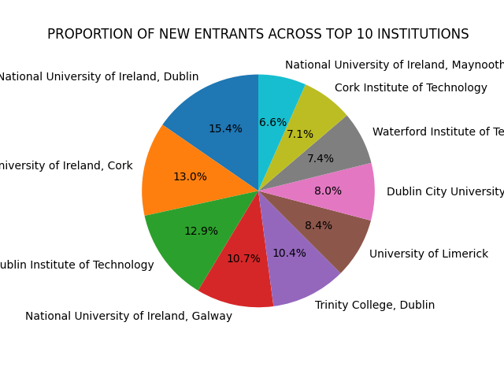

PieChart

According to the above plot, **15.4%** of the new entrants among the these top 10 institutions (considering the period 2000-2017) are enrolled in **National University of Ireland,Dublin**.

## C

Lets create a general S3 class for dataframe.

```r
# Define a S3 class for the dataframe
df_custom_class <- function(data) {
  class(data) <- c("custom_dataframe_class", class(data))
  return(data)
}
```

We can now use this class to define customised print, summary, plot functions which will be demonstrated in the coming sections.

### Print Function

Lets define a print function which will print all records in the dataframe along with its column names in a vertical fashion.

```r
# Define a print method for the S3 class
print.custom_dataframe_class <- function(df) {
  cat("Records are listed below\n-------------------------\n")

  # Iterate over each row in the dataframe
  for (i in 1:nrow(df)) {
    cat("Row ", i, ":\n")

    # Iterate over each column in the row
    for (col in names(df)) {
      cat(paste(col,":", df[i, col], "\n"))
    }

    cat("\n")  # Add a line break between rows
  }
}
# registering the S3 method(needed in Quarto)
registerS3method("print", "custom_dataframe_class", print.custom_dataframe_class)

#reading the datafile and fetching first 4 records to ensure that output is not very lengthy
education_data <- read_excel("data.xlsx") |> tail(4)

# Create an object of the custom class
my_data_custom_class <- df_custom_class(education_data)

# Print the dataframe using the custom print function
print(my_data_custom_class)
```

```
Records are listed below
-------------------------
Row  1 :
Institution : Other third level education institutions aided by DES
Year : 2014
Full-time Enrolments to Third Level Courses (Number) : 3038
Part-time Enrolments to Third Level Courses (Number) : 1980
Entrants to Third Level Courses (Number) : 856

Row  2 :
Institution : Other third level education institutions aided by DES
Year : 2015
Full-time Enrolments to Third Level Courses (Number) : 3252
Part-time Enrolments to Third Level Courses (Number) : 2001
Entrants to Third Level Courses (Number) : 885

Row  3 :
Institution : Other third level education institutions aided by DES
Year : 2016
Full-time Enrolments to Third Level Courses (Number) : 3458
Part-time Enrolments to Third Level Courses (Number) : 3403
Entrants to Third Level Courses (Number) : 880

Row  4 :
Institution : Other third level education institutions aided by DES
Year : 2017
Full-time Enrolments to Third Level Courses (Number) : 3234
Part-time Enrolments to Third Level Courses (Number) : 2996
Entrants to Third Level Courses (Number) : 786
```

The output for the print function is coming as expected.

### Summary Function

Now, lets define a function for summarizing statistical information for numerical variables in a dataframe.

```r
# Helper function to calculate mode
# this function will return first value in case frequency of occurrence for multiple values are equal to max frequency of occurrence
mode_fxn <- function(x) {
  tbl <- table(x)
  mode_out <- as.numeric(names(tbl[tbl == max(tbl)]))
  return (mode_out[1])
}
# Defining a summary method for the S3 class
summary.custom_dataframe_class <- function(df) {
  cat("Summary for the numerical columns in the provided dataframe is listed below \n----------------------------------------------------------------------------\n")

  # Iterate over each column in the dataframe
  for (col in colnames(df)) {
    if (is.numeric(df[[col]])) {
      cat("Total Entries:", sum(!is.na(df[[col]])), "\n")#preventing consideration of null values in count
      cat("Column:", col, "\n")
      cat("Mean:", mean(df[[col]],na.rm=TRUE), "\n")
      cat("Median:", median(df[[col]], na.rm = TRUE), "\n")
      cat("Mode:", mode_fxn(df[[col]]), "\n")
      cat("Variance:", var(df[[col]],na.rm=TRUE), "\n")
      cat("Standard Deviation:", sd(df[[col]],na.rm=TRUE), "\n")
      cat("\n")  # Add a line break between columns
    }
  }
}
# registering the S3 method(needed in Quarto)
registerS3method("summary", "custom_dataframe_class", summary.custom_dataframe_class)
my_data_custom_class$`Full-time Enrolments to Third Level Courses (Number)`[1] <- NA #changing to NA
summary(my_data_custom_class)
```

```
Summary for the numerical columns in the provided dataframe is listed below
----------------------------------------------------------------------------
Total Entries: 3
Column: Full-time Enrolments to Third Level Courses (Number)
Mean: 3314.667
Median: 3252
Mode: 3234
Variance: 15489.33
Standard Deviation: 124.4562

Total Entries: 4
Column: Part-time Enrolments to Third Level Courses (Number)
Mean: 2595
Median: 2498.5
Mode: 1980
Variance: 514908.7
Standard Deviation: 717.5714

Total Entries: 4
Column: Entrants to Third Level Courses (Number)
Mean: 851.75
Median: 868
Mode: 786
Variance: 2081.583
Standard Deviation: 45.62437
```

We have 3 numerical variables and we are getting the statistical summaries for all three of them which is as expected.

### Plot Function

Finally, we will create a plot function which will plot the histogram distributions for all the numerical variables present.

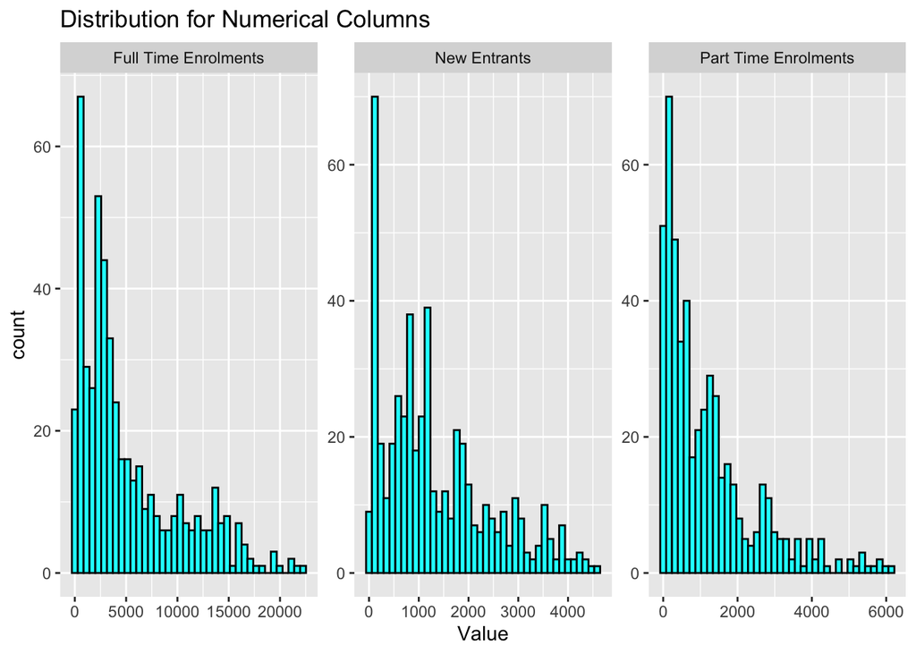

```r
# Define a plot method for the custom S3 class
plot.custom_dataframe_class <- function(df) {
  # Get numerical columns
  numeric_cols <- sapply(df, is.numeric)

  # Select numerical columns from the dataframe
  numeric_data <- df[, numeric_cols, drop = FALSE]

  # Convert data to long format for facet wrap
  df_long <- pivot_longer(numeric_data, cols = everything(), names_to = "Variable", values_to = "Value")

  # Plot histograms facetted by variable
  ggplot(df_long, aes(x = Value)) +
    geom_histogram(fill = "cyan", color ="black",bins=40) +
    facet_wrap(~Variable, scales = "free") +
    labs(title = "Distribution for Numerical Columns")
}

registerS3method("plot", "custom_dataframe_class", plot.custom_dataframe_class)

#we will be utilising our original dataframe used in part A for plotting
custom_class_data <- df_custom_class(education_data_individual_institutes)
plot(custom_class_data)
```

We can observe that the distribution graphs for all the numerical variables are coming as expected.

Note: The functions defined in this section are generalised and will work for all dataframes.